# AAProject_Group26

## Machine Learning / Aprendizagem Automática 2020/21

**ML Project - Learning about Donations**

**Grupo 26:**

> - Filipe Santos - 55142
> - Hugo Rocha - 48331
> - Paulo Correia - 22303
1. Imports
2. Understanding the Data

   ```
    2.1) Checking Duplicated Entries
    2.2) Checking the target variables TARGET_B and TARGET_D
    2.3) Adding DONATION_TYPE to the dataset
    2.4) Missing Values
    2.5) Dropping Features
   ```

3. Exploring the Data
4. Visualising the Data

**Task 1 (Supervised Learning) - Predicting Donation and Donation Type**

*Task 1.1) Predicting Donation (binary classification task) - TARGET_B*

```
    1.1.a) Linear Model - Logistic Regression
    1.1.b) Probabilistic Model - Naive Bayes
    1.1.c) Tree Model - Decision Tree
    1.1.d) Distance based Model - KNN
    1.1.e) Rule model - Apriori model
```

*Task 1.2) Predicting Donation TYPE (multiclass classification) - DONATION_TYPE*

```
    1.2.1) Preprocessing Data for Multiclass Classification
    1.2.2)  Dealing with an Unbalanced Data Problem
    1.2.3) Selection of 5 classification algorithms and model construction
            1) Linear model - SVM Model
                1.a) SVM Classifier using a one-vs-rest with an unbalanced data with 10 K-fold CV
                1.b) SVM Classifier using SMOTE with 10 K-fold CV
           2) Probabilistic model - Naive-Bayes
                2.a) Naive-Bayes with an unbalanced data with 10 K-fold CV
                2.b) Naive-Bayes using SMOTE with 10 K-fold CV
           3) Tree model - Decision Tree
                3.a) Decision Tree with an unbalanced data with 10 K-fold CV
                3.b) Decision Tree using SMOTE with 10 K-fold CV
           4) Distance-based model - KNN
                4.a) KNN with an unbalanced data with 10 K-fold CV
                4.b) KNN using SMOTE with 10 K-fold CV
           5) Rule model - Apriori
```

*Task 1.3) Training specialized models for SES*

```
    3.1) SES 1 - TARGET_B prediction
    3.2) SES 2 - TARGET_B prediction
    3.3) SES 3 - TARGET_B prediction
    3.4) SES 4 - TARGET_B prediction
```

**Task 2) Unsupervised Learning - Characterizing Donors and Donation Type**

```
    2.1) Preprocessing Data for Association Rule Mining
    2.2) Finding Associations
    2.3) Association Rules - Results and Discussion
    2.4) Preprocessing Data for Clustering
    2.5) Finding Groups
```

1. Final Comments, Limitations and Conclusions

## 1. Imports

```python
import pandas as pd
import numpy as np
import matplotlib.pyplot as plt
import seaborn as sns
import random
random.seed(42)
import numpy as np
import matplotlib.pyplot as plt
from matplotlib import cm
from matplotlib.colors import ListedColormap, LinearSegmentedColormap
```

```python
from sklearn.preprocessing import OneHotEncoder, MinMaxScaler
from sklearn.metrics import roc_curve, auc, roc_auc_score, accuracy_score, precision_score, recall_score, f1_score, confusion_matrix, classification_report
from sklearn.model_selection import train_test_split, GridSearchCV, cross_val_predict
from sklearn.metrics import classification_report
from sklearn.linear_model import LogisticRegression
from sklearn.naive_bayes import GaussianNB
from sklearn.tree import DecisionTreeClassifier
from sklearn.neighbors import KNeighborsClassifier
from mlxtend.preprocessing import TransactionEncoder
from mlxtend.frequent_patterns import apriori
from mlxtend.frequent_patterns import association_rules
from collections import Counter
from matplotlib import pyplot
import warnings
warnings.filterwarnings('ignore')
from sklearn.multiclass import OneVsRestClassifier
from sklearn import svm
from sklearn.svm import SVC
from sklearn.multiclass import OneVsRestClassifier
from sklearn.preprocessing import label_binarize
from scipy import interp
from itertools import cycle
from sklearn.cluster import AgglomerativeClustering
from sklearn.model_selection import KFold
from imblearn.over_sampling import SMOTE
```

```python
donors = pd.read_csv("Donors_dataset.csv", header=0, na_values="?")

pd.set_option('display.max_columns', None)
donors.head(3)
```

|  | TARGET_B | TARGET_D | CONTROL_NUMBER | MONTHS_SINCE_ORIGIN | DONOR_AGE | IN_HOUSE | URBANICITY | SES | CLUSTER_CODE | HOME_OWNER | DONOR_GENDER | INCOME_GROUP | PUBLISHED_PHONE | OVERLAY_SOURCE | MOR_HIT_RATE | WEALTH_RATING | MEDIAN_HOME_VALUE | MEDIAN_HOUSEHOLD_INCOME | PCT_OWNER_OCCUPIED | PER_CAPITA_INCOME | PCT_ATTRIBUTE1 | PCT_ATTRIBUTE2 | PCT_ATTRIBUTE3 | PCT_ATTRIBUTE4 | PEP_STAR | RECENT_STAR_STATUS | RECENCY_STATUS_96NK | FREQUENCY_STATUS_97NK | RECENT_RESPONSE_PROP | … |
| --- | --- | --- | --- | --- | --- | --- | --- | --- | --- | --- | --- | --- | --- | --- | --- | --- | --- | --- | --- | --- | --- | --- | --- | --- | --- | --- | --- | --- | --- | --- |
| 0 | 0 | NaN | 5 | 101 | 87.0 | 0 | NaN | NaN | . | H | M | 2.0 | 0 | P | 0 | NaN | 554 | 294 | 76 | 11855 | 0 | 0 | 0 | 0 | 1 | 0 | A | 1 | 0.067 | … |
| 1 | 1 | 10.0 | 12 | 137 | 79.0 | 0 | R | 2.0 | 45 | H | M | 7.0 | 0 | P | 0 | 3.0 | 334 | 212 | 72 | 10385 | 0 | 41 | 21 | 31 | 1 | 1 | S | 2 | 0.235 | … |
| 2 | 0 | NaN | 37 | 113 | 75.0 | 0 | S | 1.0 | 11 | H | F | 5.0 | 0 | P | 0 | 9.0 | 2388 | 405 | 63 | 30855 | 0 | 25 | 26 | 57 | 1 | 1 | S | 3 | 0.409 | … |

## 2. Understanding the Data

In this task you should **understand better the features**, their distribution of values, potential errors, etc and plan/describe what data preprocessing steps should be performed next. Very important also is to check the distribution of values in the target (class distribution).

Here you can find a notebook with some examples of what you can do in **Exploratory Data Analysis**: https://www.kaggle.com/artgor/exploration-of-data-step-by-step/notebook. You can also use Orange widgets for this.

```python
donors.shape
```

```
(19372, 50)
```

```python
donors.info()
```

```
<class 'pandas.core.frame.DataFrame'>
RangeIndex: 19372 entries, 0 to 19371
Data columns (total 50 columns):
 #   Column                       Non-Null Count  Dtype
---  ------                       --------------  -----
 0   TARGET_B                     19372 non-null  int64
 1   TARGET_D                     4843 non-null   float64
 2   CONTROL_NUMBER               19372 non-null  int64
 3   MONTHS_SINCE_ORIGIN          19372 non-null  int64
 4   DONOR_AGE                    14577 non-null  float64
 5   IN_HOUSE                     19372 non-null  int64
 6   URBANICITY                   18918 non-null  object
 7   SES                          18918 non-null  float64
 8   CLUSTER_CODE                 19372 non-null  object
 9   HOME_OWNER                   19372 non-null  object
```

[output cut: 42 more lines]

There are a total of 19372 entries in the dataset and 50(!) features.

```python
donors.describe()
```

|  | TARGET_B | TARGET_D | CONTROL_NUMBER | MONTHS_SINCE_ORIGIN | DONOR_AGE | IN_HOUSE | SES | INCOME_GROUP | PUBLISHED_PHONE | MOR_HIT_RATE | WEALTH_RATING | MEDIAN_HOME_VALUE | MEDIAN_HOUSEHOLD_INCOME | PCT_OWNER_OCCUPIED | PER_CAPITA_INCOME | PCT_ATTRIBUTE1 | PCT_ATTRIBUTE2 | PCT_ATTRIBUTE3 | PCT_ATTRIBUTE4 | PEP_STAR | RECENT_STAR_STATUS | FREQUENCY_STATUS_97NK | RECENT_RESPONSE_PROP | RECENT_AVG_GIFT_AMT | RECENT_CARD_RESPONSE_PROP | RECENT_AVG_CARD_GIFT_AMT | RECENT_RESPONSE_COUNT | RECENT_CARD_RESPONSE_COUNT | MONTHS_SINCE_LAST_PROM_RESP | … |
| --- | --- | --- | --- | --- | --- | --- | --- | --- | --- | --- | --- | --- | --- | --- | --- | --- | --- | --- | --- | --- | --- | --- | --- | --- | --- | --- | --- | --- | --- | --- |
| count | 19372.000000 | 4843.000000 | 19372.000000 | 19372.000000 | 14577.000000 | 19372.000000 | 18918.000000 | 14980.000000 | 19372.000000 | 19372.000000 | 10562.000000 | 19372.000000 | 19372.000000 | 19372.000000 | 19372.000000 | 19372.000000 | 19372.000000 | 19372.000000 | 19372.000000 | 19372.000000 | 19372.000000 | 19372.000000 | 19372.000000 | 19372.000000 | 19372.000000 | 19372.00000 | 19372.000000 | 19372.000000 | 19126.000000 | … |
| mean | 0.250000 | 15.624344 | 96546.225377 | 73.409973 | 58.919051 | 0.073198 | 1.903425 | 3.907543 | 0.497729 | 3.361656 | 5.005397 | 1079.871929 | 341.970215 | 69.698999 | 15857.334452 | 1.029011 | 30.573921 | 29.603293 | 32.852467 | 0.504439 | 0.931138 | 1.983998 | 0.190127 | 15.365396 | 0.230808 | 11.68547 | 3.043103 | 1.730539 | 19.038900 | … |
| std | 0.433024 | 12.445137 | 55830.643871 | 41.255574 | 16.669382 | 0.260469 | 0.749215 | 1.864796 | 0.500008 | 9.503481 | 2.815386 | 960.753448 | 164.207807 | 21.711019 | 8710.630390 | 4.918297 | 11.421471 | 15.120360 | 17.839765 | 0.499993 | 2.545585 | 1.099346 | 0.113947 | 10.167485 | 0.186230 | 10.83412 | 2.046401 | 1.535521 | 3.415559 | … |
| min | 0.000000 | 1.000000 | 5.000000 | 5.000000 | 0.000000 | 0.000000 | 1.000000 | 1.000000 | 0.000000 | 0.000000 | 0.000000 | 0.000000 | 0.000000 | 0.000000 | 0.000000 | 0.000000 | 0.000000 | 0.000000 | 0.000000 | 0.000000 | 0.000000 | 1.000000 | 0.000000 | 0.000000 | 0.000000 | 0.00000 | 0.000000 | 0.000000 | -12.000000 | … |
| 25% | 0.000000 | 10.000000 | 48289.000000 | 29.000000 | 47.000000 | 0.000000 | 1.000000 | 2.000000 | 0.000000 | 0.000000 | 3.000000 | 518.000000 | 232.000000 | 60.000000 | 10869.000000 | 0.000000 | 25.000000 | 20.000000 | 21.000000 | 0.000000 | 0.000000 | 1.000000 | 0.105000 | 10.000000 | 0.100000 | 5.00000 | 2.000000 | 1.000000 | 17.000000 | … |
| 50% | 0.000000 | 13.000000 | 96937.000000 | 65.000000 | 60.000000 | 0.000000 | 2.000000 | 4.000000 | 0.000000 | 0.000000 | 5.000000 | 747.000000 | 311.000000 | 76.000000 | 13816.500000 | 0.000000 | 31.000000 | 29.000000 | 32.000000 | 1.000000 | 0.000000 | 2.000000 | 0.167000 | 14.000000 | 0.200000 | 10.14000 | 3.000000 | 1.000000 | 18.000000 | … |
| 75% | 0.250000 | 20.000000 | 145429.500000 | 113.000000 | 73.000000 | 0.000000 | 2.000000 | 5.000000 | 1.000000 | 3.000000 | 7.000000 | 1227.000000 | 417.000000 | 85.000000 | 18308.250000 | 0.000000 | 37.000000 | 39.000000 | 43.000000 | 1.000000 | 1.000000 | 3.000000 | 0.250000 | 20.000000 | 0.333000 | 16.00000 | 4.000000 | 2.000000 | 21.000000 | … |
| max | 1.000000 | 200.000000 | 191779.000000 | 137.000000 | 87.000000 | 1.000000 | 4.000000 | 7.000000 | 1.000000 | 241.000000 | 9.000000 | 6000.000000 | 1500.000000 | 99.000000 | 174523.000000 | 97.000000 | 99.000000 | 99.000000 | 99.000000 | 1.000000 | 22.000000 | 4.000000 | 1.000000 | 260.000000 | 1.000000 | 300.00000 | 16.000000 | 9.000000 | 36.000000 | … |

Another quick way to get a feel of the type of data we are dealing with is to plot a histogram for each one of the numerical attributes. We will explore the features further ahead in the project, this is just an initial overview.

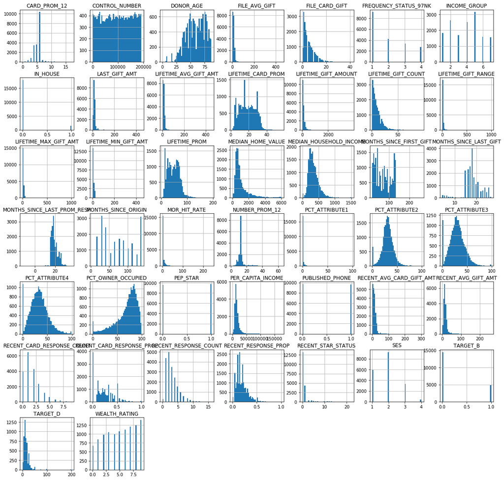

```python
donors.hist(bins=50, figsize=(20,20))
plt.show();
```

```python
donors.describe(include=np.object)
```

|  | URBANICITY | CLUSTER_CODE | HOME_OWNER | DONOR_GENDER | OVERLAY_SOURCE | RECENCY_STATUS_96NK |
| --- | --- | --- | --- | --- | --- | --- |
| count | 18918 | 19372 | 19372 | 19372 | 19372 | 19372 |
| unique | 5 | 54 | 2 | 4 | 4 | 6 |
| top | S | 40 | H | F | B | A |
| freq | 4491 | 830 | 10606 | 10401 | 8732 | 11918 |

After a first look at the dataset and its feature, we can split the variables in two main groups:

- **Demographic:** these are related to the donor and their demographics. `DONOR_AGE`, `DONOR_GENDER`, `INCOME_GROUP`, `MEDIAN_HOUSEHOLD_INCOME`, `URBANICITY` are some examples of features that pertain to the donor and their social and economic reality.
- **Donation:** these are related to the donor's donation history and other charity functional features: `PEP_STAR`, `IN_HOUSE`, `PUBLISHED_PHONE`, `FREQUENCY_STATUS_97NK` are some examples of this type.

## 2.1. Checking Duplicated Entries

```python
if donors.shape[0] == len(donors.CONTROL_NUMBER.unique()):
    print('There are no duplicated entries in this dataset.')
else:
    print('There are {} duplicated entries'.format(donors.shape[0] - len(donors.CONTROL_NUMBER.unique())))
```

```
There are no duplicated entries in this dataset.
```

## 2.2. Checking the target variables TARGET_B and TARGET_D

```python
print("Total number of non-donors (0) = {}, {} percent of total".format(donors[donors['TARGET_B']==0].shape[0], donors[donors['TARGET_B']==0].shape[0]/donors.shape[0]*100))
print("Total number of donors (1) = {}, {} percent of total".format(donors[donors['TARGET_B']==1].shape[0], donors[donors['TARGET_B']==1].shape[0]/donors.shape[0]*100))
```

```
Total number of non-donors (0) = 14529, 75.0 percent of total
Total number of donors (1) = 4843, 25.0 percent of total
```

We can conclude that the data is not balanced; that is, our two target classes from the feature 'TARGET_B', donors (1) and non-donors (0), are not represented equally in the dataset. Only a small part of the individuals donated. As we will see further ahead in the project, this will imply some restrictions when choosing which performance metrics to measure.

```python
pd.DataFrame(donors['TARGET_D'].value_counts()) #checking the counts of unique values of TARGET_D
```

|  | TARGET_D |
| --- | --- |
| 10.00 | 941 |
| 15.00 | 591 |
| 20.00 | 577 |
| 5.00 | 503 |
| 25.00 | 392 |
| ... | ... |
| 16.87 | 1 |
| 101.00 | 1 |
| 13.92 | 1 |
| 5.25 | 1 |
| 55.00 | 1 |

70 rows × 1 columns

```python
pd.DataFrame(donors['TARGET_D'].describe()) #checking some statistical details of TARGET_D
```

|  | TARGET_D |
| --- | --- |
| count | 4843.000000 |
| mean | 15.624344 |
| std | 12.445137 |
| min | 1.000000 |
| 25% | 10.000000 |
| 50% | 13.000000 |
| 75% | 20.000000 |
| max | 200.000000 |

When analysing TARGET_D, we can observe that there were 4843 donations as a response to last year's soliciation, with the mean close to $15.6.

Half of individuals have donated $13 or less, while the max donation summed up to 200 dollars.

## 2.3. Adding DONATION_TYPE to the dataset

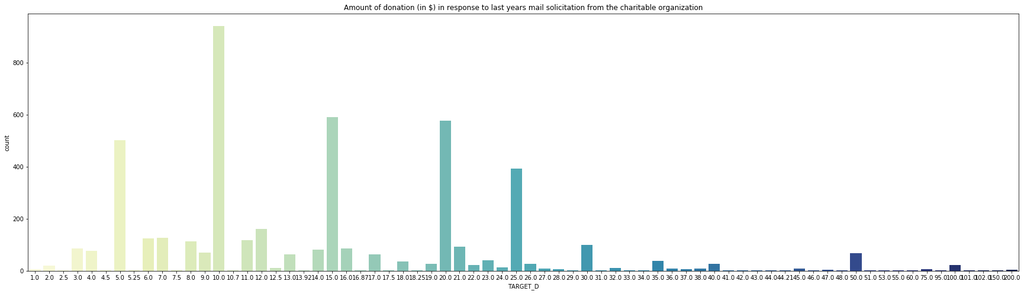

```python
fig, ax = plt.subplots(1, 1, figsize=(8,4))
g=sns.countplot(donors['TARGET_D'], palette='YlGnBu')
plt.title('Amount of donation (in $) in response to last years mail solicitation from the charitable organization')
g.figure.set_size_inches(30,8)
plt.show();
```

```python
donors['TARGET_D'].describe()
```

```
count    4843.000000
mean       15.624344
std        12.445137
min         1.000000
25%        10.000000
50%        13.000000
75%        20.000000
max       200.000000
Name: TARGET_D, dtype: float64
```

Based on the data distrubtion, we have taken considered the following cut offs to define a new feature named `DONATION_TYPE`, whose values describe ranges of the donation amount (DA) reported in feature `TARGET_D` when it takes up a value different that zero, that is, when an individual is a donor:

- `A` - DA >= 50
- `B` - 20 <= DA < 50
- `C` - 13 <= DA < 20
- `D` - 10 <= DA < 13
- `E` - DA < 10

```python
# creating a list for our classes according to the different threshold donations
thresholds = [
    (donors['TARGET_D']  >= 50),
    (donors['TARGET_D'] < 50) & (donors['TARGET_D']  >= 20),
    (donors['TARGET_D'] < 20) & (donors['TARGET_D']  >= 13),
    (donors['TARGET_D'] < 13) & (donors['TARGET_D']  >= 10),
    (donors['TARGET_D'] < 10)
    ]

# creating a list of the classes
values = ['A', 'B', 'C', 'D', 'E']

# creating a new column, representing an ordinal feature
#using np.select to assign values to DONATION_TYPE using the above lists as arguments
donors['DONATION_TYPE'] = np.select(thresholds, values, default=np.nan)
```

```python
donors['DONATION_TYPE']
```

```
0        nan
1          D
2        nan
3        nan
4        nan
        ...
19367    nan
19368    nan
19369    nan
19370    nan
19371      A
Name: DONATION_TYPE, Length: 19372, dtype: object
```

It is important to highlight that when 'DONATION_TYPE' takes up a value different than the classes created above (A,B,C,D,E), it is due to the fact that the individual is a non-donor.

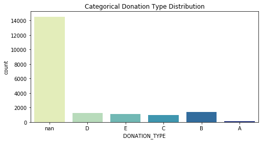

```python
fig, ax = plt.subplots(1, 1, figsize=(8,4))
sns.countplot(donors['DONATION_TYPE'], palette='YlGnBu')
plt.xlabel('DONATION_TYPE')
plt.title('Categorical Donation Type Distribution')
plt.show();
```

We had already known that we were dealing with an imbalanced dataset (75% non-donors represented by the 'nan' column), the above bar chart highlights the high value donations >= 50 dollars were the least common in last year's donation.

## 2.4. Missing Values

```python
na_found=donors.isna().sum().any()
if na_found==True:
    total_na = donors.isnull().sum()
    percent_na = round(donors.isnull().sum()/donors.isnull().count()*100,5)
    donors_df2 = pd.concat([percent_na, total_na], axis=1, keys=["% of NA", "Total NA"])
    dtypes = []
    for i in donors.columns:
        dtype = str(donors[i].dtype)
        dtypes.append(dtype)
    donors_df2['Type'] = dtypes
    donors_df2 = donors_df2.sort_values('% of NA', ascending=False)
donors_df2
```

|  | % of NA | Total NA | Type |
| --- | --- | --- | --- |
| TARGET_D | 75.00000 | 14529 | float64 |
| WEALTH_RATING | 45.47801 | 8810 | float64 |
| DONOR_AGE | 24.75222 | 4795 | float64 |
| INCOME_GROUP | 22.67190 | 4392 | float64 |
| URBANICITY | 2.34359 | 454 | object |
| SES | 2.34359 | 454 | float64 |
| MONTHS_SINCE_LAST_PROM_RESP | 1.26987 | 246 | float64 |
| TARGET_B | 0.00000 | 0 | int64 |
| LIFETIME_AVG_GIFT_AMT | 0.00000 | 0 | float64 |
| RECENT_AVG_CARD_GIFT_AMT | 0.00000 | 0 | float64 |
| RECENT_RESPONSE_COUNT | 0.00000 | 0 | int64 |
| RECENT_CARD_RESPONSE_COUNT | 0.00000 | 0 | int64 |
| LIFETIME_CARD_PROM | 0.00000 | 0 | int64 |
| LIFETIME_PROM | 0.00000 | 0 | int64 |
| LIFETIME_GIFT_AMOUNT | 0.00000 | 0 | float64 |
| LIFETIME_GIFT_COUNT | 0.00000 | 0 | int64 |
| LIFETIME_MAX_GIFT_AMT | 0.00000 | 0 | float64 |
| LIFETIME_GIFT_RANGE | 0.00000 | 0 | float64 |
| RECENT_AVG_GIFT_AMT | 0.00000 | 0 | float64 |
| LIFETIME_MIN_GIFT_AMT | 0.00000 | 0 | float64 |
| LAST_GIFT_AMT | 0.00000 | 0 | float64 |
| CARD_PROM_12 | 0.00000 | 0 | int64 |
| NUMBER_PROM_12 | 0.00000 | 0 | int64 |
| MONTHS_SINCE_LAST_GIFT | 0.00000 | 0 | int64 |
| MONTHS_SINCE_FIRST_GIFT | 0.00000 | 0 | int64 |
| FILE_AVG_GIFT | 0.00000 | 0 | float64 |
| FILE_CARD_GIFT | 0.00000 | 0 | int64 |
| RECENT_CARD_RESPONSE_PROP | 0.00000 | 0 | float64 |
| RECENT_STAR_STATUS | 0.00000 | 0 | int64 |
| RECENT_RESPONSE_PROP | 0.00000 | 0 | float64 |
| FREQUENCY_STATUS_97NK | 0.00000 | 0 | int64 |
| CONTROL_NUMBER | 0.00000 | 0 | int64 |
| MONTHS_SINCE_ORIGIN | 0.00000 | 0 | int64 |
| IN_HOUSE | 0.00000 | 0 | int64 |
| CLUSTER_CODE | 0.00000 | 0 | object |
| HOME_OWNER | 0.00000 | 0 | object |
| DONOR_GENDER | 0.00000 | 0 | object |
| PUBLISHED_PHONE | 0.00000 | 0 | int64 |
| OVERLAY_SOURCE | 0.00000 | 0 | object |
| MOR_HIT_RATE | 0.00000 | 0 | int64 |
| MEDIAN_HOME_VALUE | 0.00000 | 0 | int64 |
| MEDIAN_HOUSEHOLD_INCOME | 0.00000 | 0 | int64 |
| PCT_OWNER_OCCUPIED | 0.00000 | 0 | int64 |
| PER_CAPITA_INCOME | 0.00000 | 0 | int64 |
| PCT_ATTRIBUTE1 | 0.00000 | 0 | int64 |
| PCT_ATTRIBUTE2 | 0.00000 | 0 | int64 |
| PCT_ATTRIBUTE3 | 0.00000 | 0 | int64 |
| PCT_ATTRIBUTE4 | 0.00000 | 0 | int64 |
| PEP_STAR | 0.00000 | 0 | int64 |
| RECENCY_STATUS_96NK | 0.00000 | 0 | object |
| DONATION_TYPE | 0.00000 | 0 | object |

Seven features were found to have missing values. It is important to highlight that the target variable `TARGET_D` has a considerable number of NAs, totalling 75% of the observations - as confirmed previously, this is due to the fact that 75% of individuals have not donated, hence their amount of donation does not exist.

For these features we will have to find different imputation methods.

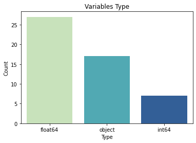

```python
#feature type distribution
fig,ax = plt.subplots()
sns.barplot(data=donors_df2,x=donors_df2.Type.unique(), y=donors_df2.Type.value_counts(),ax=ax, palette='YlGnBu')
ax.set(xlabel='Type', ylabel='Count',title="Variables Type");
```

```python
 list(donors.columns[donors.isnull().any()]) #getting a list of features with missing values
```

```
['TARGET_D',
 'DONOR_AGE',
 'URBANICITY',
 'SES',
 'INCOME_GROUP',
 'WEALTH_RATING',
 'MONTHS_SINCE_LAST_PROM_RESP']
```

- Starting with `DONOR_AGE`, we can impute the median for this variable for every NA as it is an easy method that does not affect this variable's distribution.

```python
ageMedian = donors["DONOR_AGE"].median()
donors["DONOR_AGE"] = donors["DONOR_AGE"].fillna(ageMedian)
donors["DONOR_AGE"].isnull().sum()
```

```
0
```

```python
donors['DONOR_AGE']=donors['DONOR_AGE'].astype('int64')
```

- Next we take a look at `INCOME_GROUP` and `WEALTH_RATING`, which are both categorical variables.

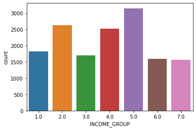

```python
sns.countplot(x=donors['INCOME_GROUP'])
plt.show()
```

```python
donors['INCOME_GROUP'].value_counts(normalize=True) * 100
```

```
5.0    21.021362
2.0    17.530040
4.0    16.862483
1.0    12.162884
3.0    11.341789
6.0    10.620828
7.0    10.460614
Name: INCOME_GROUP, dtype: float64
```

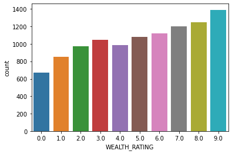

```python
sns.countplot(x=donors['WEALTH_RATING'])
plt.show()
```

```python
donors['WEALTH_RATING'].value_counts(normalize=True) * 100
```

```
9.0    13.160386
8.0    11.815944
7.0    11.352017
6.0    10.575649
5.0    10.206400
3.0     9.903427
4.0     9.344821
2.0     9.221738
1.0     8.085590
0.0     6.334028
Name: WEALTH_RATING, dtype: float64
```

One way to treat these missing values would be to impute the mode to all missing values of these two features. However, as the number of missing values is too high, this would severely impact the dataset and greatly skew the observations towards the most frequent class. In this case, the mode would refer to classes 5 and 9, for `INCOME_GROUP` and `WEALTH_RATING` respectively.

We also can't just remove the rows with NA values because that would cut almost half of the dataset. A possible solution would be to evaluate if these two features are needed, as there could be features that show the same type of information as these two. In this case, we are looking for features that convey economic information about the donors.

Looking at the dataset, there are other features that represent economic data: `PER_CAPITA_INCOME`, `MEDIAN_HOUSEHOLD_INCOME` and `SES`. It can be interesting to look at the correlation between `WEALTH_RATING` and `INCOME_GROUP` and these features.

```python
donors.corrwith(donors["WEALTH_RATING"]).sort_values(ascending=False).head()
```

```
WEALTH_RATING              1.000000
MEDIAN_HOUSEHOLD_INCOME    0.603792
PER_CAPITA_INCOME          0.521337
INCOME_GROUP               0.419194
MEDIAN_HOME_VALUE          0.390796
dtype: float64
```

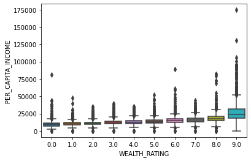

```python
sns.boxplot(x = 'WEALTH_RATING', y = 'PER_CAPITA_INCOME', data = donors)
```

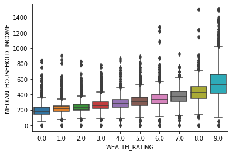

```python
sns.boxplot(x = 'WEALTH_RATING', y = 'MEDIAN_HOUSEHOLD_INCOME', data = donors)
```

`PER_CAPITA_INCOME` and `MEDIAN_HOUSEHOLD_INCOME`seem to display the same information as `WEALTH_RATING`.

```python
donors.corrwith(donors["INCOME_GROUP"]).sort_values(ascending=False).head()
```

```
INCOME_GROUP               1.000000
MEDIAN_HOUSEHOLD_INCOME    0.428270
WEALTH_RATING              0.419194
PER_CAPITA_INCOME          0.354530
MEDIAN_HOME_VALUE          0.323530
dtype: float64
```

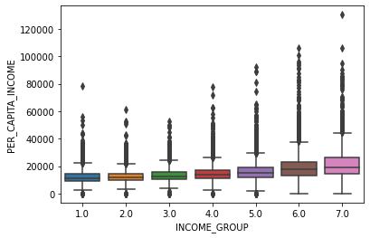

```python
sns.boxplot(x = 'INCOME_GROUP', y = 'PER_CAPITA_INCOME', data = donors)
```

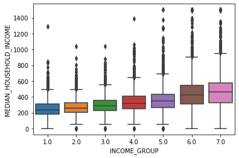

```python
sns.boxplot(x = 'INCOME_GROUP', y = 'MEDIAN_HOUSEHOLD_INCOME', data = donors)
```

We have observed that both `INCOME_GROUP` and `WEALTH_RATING` show some correlation with other economic features. We will assume that both of these two features were generated to represent groups based on data from the economic features and, as such, we can remove them from the dataset and still keep the information that these two features convey.

```python
donors = donors.drop(["INCOME_GROUP", "WEALTH_RATING"], axis=1)
```

- For `SES` and `URBANICITY`, we have chosen to replace the missing values by the most common class for each feature. There isn't a big problem with data skewage like we saw before with `INCOME_GROUP` and `WEALTH_RATING` because the number of missing values is much lower (about 2.34% for `SES` and `URBANICITY`).

```python
donors['SES'].value_counts()
```

```
2.0    9284
1.0    5924
3.0    3323
4.0     387
Name: SES, dtype: int64
```

```python
donors['SES'] = donors['SES'].fillna(donors['SES'].mode()[0])
```

```python
donors["SES"].isnull().sum()
```

```
0
```

```python
donors['URBANICITY'].value_counts()
```

```
S    4491
C    4022
R    4005
T    3944
U    2456
Name: URBANICITY, dtype: int64
```

```python
donors['URBANICITY'] = donors['URBANICITY'].fillna(donors['URBANICITY'].mode()[0])
```

```python
donors["SES"].isnull().sum()
```

```
0
```

**OTHER OPTIONS:**

- try to find similar donors to the ones that have these values as NA and infer the missing values - maybe through a clustering method.
- Create a new group 'UNKNOWN' and fill these missing values with that group.
- `MONTHS_SINCE_LAST_PROM_RESP` is the feature with the least amount of missing values. We'd also observed before in the dataset describe method that `MONTHS_SINCE_LAST_PROM_RESP` had negative values. From the dataset description we can see that this feature represents the number of months since the donor's last response. That means that there shouldn't be any negative values.

```python
donors["MONTHS_SINCE_LAST_PROM_RESP"].describe()
```

```
count    19126.000000
mean        19.038900
std          3.415559
min        -12.000000
25%         17.000000
50%         18.000000
75%         21.000000
max         36.000000
Name: MONTHS_SINCE_LAST_PROM_RESP, dtype: float64
```

We should see how many negative values there are.

```python
negSum = 0
for val in donors["MONTHS_SINCE_LAST_PROM_RESP"]:
    if val < 0:
        negSum += 1
print("There are", str(negSum), "negative values in this feature!")
```

```
There are 8 negative values in this feature!
```

```python
donors[donors['MONTHS_SINCE_LAST_PROM_RESP']<0].LIFETIME_CARD_PROM
```

```
203      34
5214     17
5807     19
6682     15
8343     15
9601     32
10391    31
13456    18
Name: LIFETIME_CARD_PROM, dtype: int64
```

There are 8 negative values in `MONTHS_SINCE_LAST_PROM_RESP`.

After checking `LIFETIME_CARD_PROM`, we confirmed that the entries which had a negative value of `MONTHS_SINCE_LAST_PROM_RESP` actually had positive values representing the total number of card promotions sent to the individual by the charitable organization. With this, we could discard the idea that those individuals had been first time donors.

```python
donors["MONTHS_SINCE_LAST_PROM_RESP"] = donors["MONTHS_SINCE_LAST_PROM_RESP"].fillna(
    donors["MONTHS_SINCE_LAST_PROM_RESP"].median())

donors["MONTHS_SINCE_LAST_PROM_RESP"].isnull().sum()
```

```
0
```

- Finally, for `TARGET_D`, we will first verify if all the null values are indeed from non-donors.

```python
donors[donors["TARGET_B"]==1]["TARGET_D"].isnull().sum()
```

```
0
```

Having confirmed this assumption, we can input missing values with zero. If someone didn't donate then TARGET_B = 0 and, obviously, TARGET_D = 0. However, this would interfere with `DONATION_TYPE`, as all the non-donors would be added to type E and heavily skew the data towards this class. As such, we will leave these values as NA's.

```python
donors.columns[donors.isnull().any()] #sanity check
```

```
Index(['TARGET_D'], dtype='object')
```

Seeing that only `TARGET_D` has missing values, we can proceed with the analysis.

### Other problems in the data

- `MEDIAN_HOME_VALUE`: We had previously identified a problem with this feature, where it was equal to 0 in some observations. Because a home always has a non-zero value (unless the person who is donated is homeless, which does not seem likely), we will have to treat these values. We will do what we did before for the missing values and replace these ones with the median for this feature.

```python
donors["MEDIAN_HOME_VALUE"] = np.where((donors["MEDIAN_HOME_VALUE"] == 0),
                                       donors['MEDIAN_HOME_VALUE'].median(),
                                       donors["MEDIAN_HOME_VALUE"])
donors['MEDIAN_HOME_VALUE'].describe()
```

```
count    19372.000000
mean      1088.278185
std        954.515594
min         75.000000
25%        529.000000
50%        747.000000
75%       1227.000000
max       6000.000000
Name: MEDIAN_HOME_VALUE, dtype: float64
```

## 2.5. Dropping Features

Looking at the features' descriptions, we can immediately point out some that are meaningless for the problem at hand and, hence, will be dropped:

- CONTROL_NUMBER: this is a unique identifier for each donor, it has no impact in the donation.
- OVERLAY_SOURCE: we will assume that the data source is not relevant for the prediction.
- FILE_AVG_GIFT: this feature is identical to LIFETIME_AVG_GIFT_AMT, according to the dataset info.
- PEP_STAR: which takes up value 1 if the donor has a STAR status and 0 otherwise will be removed as this information is already displayed in the feature 'RECENCY_STATUS_96NK' by the class S and by the remaining ones, respectively.
- RECENT_STAR_STATUS: which takes up value 1 if the donor has reached STAR status 4 years ago and 0 otherwise will be removed as this information is already displayed in the feature 'RECENCY_STATUS_96NK' by the class S and by the remaining ones, respectively.
- CLUSTER_CODE: There are 54 unique values for this variable. Given that this feature reflects socioeconomic status, urbanicity, ethnicity, and other demographic characteristics, we consider that such information is already reflected in other features of this dataset so we will drop it.
- NUMBER_PROM_12: the data illustrated in this feature is already represented by the feature 'CARD_PROM_12'
- PCT_ATTRIBUTE3 and PCT_ATTRIBUTE4: these features show the % of veterans of WWII and Vietnam in the neighborhood where the donor lives. However, the % of all veterans is already in PCT_ATTRIBUTE2. This means these features are redundant and should be dropped. Also, we should rename PCT_ATTRIBUTE1 and 2 to something more clear: 1 to PCT_MILITARY and 2 to PCT_VETERANS

```python
donors=donors.drop(['CONTROL_NUMBER', 'OVERLAY_SOURCE', 'FILE_AVG_GIFT', 'PEP_STAR',
                    'RECENT_STAR_STATUS', 'PCT_ATTRIBUTE3', 'PCT_ATTRIBUTE4',
                   'CLUSTER_CODE','NUMBER_PROM_12'],axis=1)
```

```python
donors=donors.rename(columns = {'PCT_ATTRIBUTE1':'PCT_MILITARY', 'PCT_ATTRIBUTE2':'PCT_VETERANS'})
```

We will also look for correlations in the data set and, after analysing pairs of features with a positively high standard correlation coefficient, we have chosen to remove the following features:

- 'MONTHS_SINCE_ORIGIN'
- 'LIFETIME_PROM_CARD'
- 'PER_CAPITA_INCOME'
- 'LIFETIME_GIFT_COUNT'
- 'LIFETIME_MAX_GIFT_AMT'
- 'LIFETIME_MIN_GIFT_AMT'
- 'LIFETIME_GIFT_RANGE'
- 'LIFETIME_PROM'
- 'RECENT_RESPONSE_COUNT'
- 'LIFETIME_GIFT_AMOUNT'

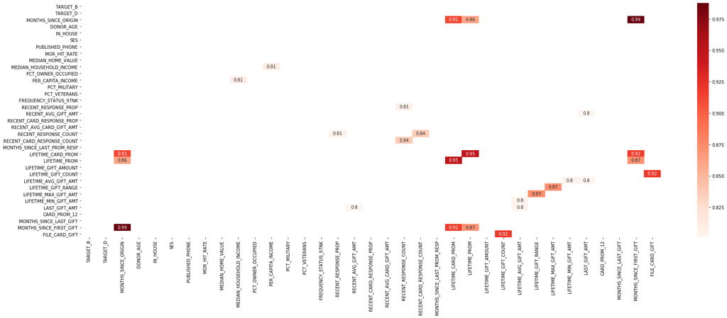

```python
donors_matrix = donors.corr()
filtered_donors = donors_matrix[((donors_matrix >= .8) | (donors_matrix <= -.8)) & (donors_matrix !=1.000)]
plt.figure(figsize=(30,10))
sns.heatmap(filtered_donors, annot=True, cmap="Reds")

plt.show()
```

```python
filtered_donors.unstack().sort_values().drop_duplicates()
```

```
RECENT_AVG_GIFT_AMT      LAST_GIFT_AMT                 0.801052
LAST_GIFT_AMT            LIFETIME_AVG_GIFT_AMT         0.803911
LIFETIME_AVG_GIFT_AMT    LIFETIME_MIN_GIFT_AMT         0.804668
RECENT_RESPONSE_PROP     RECENT_RESPONSE_COUNT         0.805832
MEDIAN_HOUSEHOLD_INCOME  PER_CAPITA_INCOME             0.811624
RECENT_RESPONSE_COUNT    RECENT_CARD_RESPONSE_COUNT    0.836973
MONTHS_SINCE_ORIGIN      LIFETIME_PROM                 0.860342
MONTHS_SINCE_FIRST_GIFT  LIFETIME_PROM                 0.870775
LIFETIME_MAX_GIFT_AMT    LIFETIME_GIFT_RANGE           0.871837
MONTHS_SINCE_ORIGIN      LIFETIME_CARD_PROM            0.912063
LIFETIME_CARD_PROM       MONTHS_SINCE_FIRST_GIFT       0.916866
LIFETIME_GIFT_COUNT      FILE_CARD_GIFT                0.918308
LIFETIME_PROM            LIFETIME_CARD_PROM            0.948653
MONTHS_SINCE_ORIGIN      MONTHS_SINCE_FIRST_GIFT       0.987825
TARGET_B                 TARGET_B                           NaN
dtype: float64
```

```python
donors = donors.drop(['MONTHS_SINCE_ORIGIN','LIFETIME_CARD_PROM','PER_CAPITA_INCOME','LIFETIME_GIFT_COUNT',
 'LIFETIME_MAX_GIFT_AMT', 'LIFETIME_MIN_GIFT_AMT',
 'LIFETIME_GIFT_RANGE','LIFETIME_PROM', 'RECENT_RESPONSE_COUNT','LIFETIME_GIFT_AMOUNT'], axis=1)
```

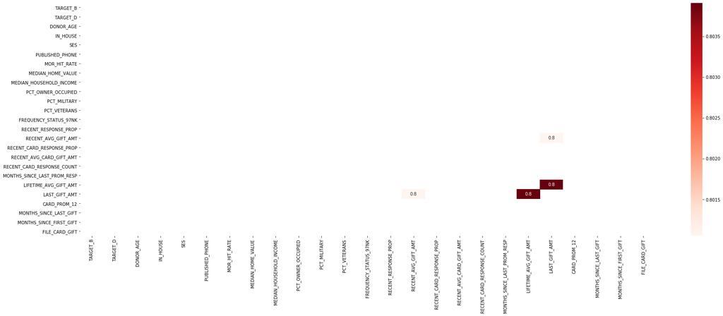

```python
donors_matrix = donors.corr()
filtered_donors = donors_matrix[((donors_matrix >= .8) | (donors_matrix <= -.8)) & (donors_matrix !=1.000)]
plt.figure(figsize=(30,10))
sns.heatmap(filtered_donors, annot=True, cmap="Reds")

plt.show()
```

Two highly correlated pairs (corr > 0.8) remain: `RECENT_AVG_GIFT_AMT`-`LAST_GIFT_AMT` and `LAST_GIFT_AMT`-`LIFETIME_AVG_GIFT_AMT`. However, despite the correlation being high, we can't really remove one of them as the information present in each feature is not redundant, that is, there is information that one of these features alone cannot explain. As such, we will leave these 3 features in the dataset.

# 3. Exploring Data

The amount of NA's in `TARGET_D` might make it difficult to interpret plots. We will create a subset of the donors dataset with only active donors, that is, people who actually donated in the last campaign (`TARGET_B`=1).

```python
activeIndex = []
for i in donors.index:
    if donors["TARGET_B"][i] == 1:
        activeIndex.append(i)

len(activeIndex)
```

```
4843
```

```python
activedonors = donors.loc[activeIndex]
activedonors.head(2)
```

|  | TARGET_B | TARGET_D | DONOR_AGE | IN_HOUSE | URBANICITY | SES | HOME_OWNER | DONOR_GENDER | PUBLISHED_PHONE | MOR_HIT_RATE | MEDIAN_HOME_VALUE | MEDIAN_HOUSEHOLD_INCOME | PCT_OWNER_OCCUPIED | PCT_MILITARY | PCT_VETERANS | RECENCY_STATUS_96NK | FREQUENCY_STATUS_97NK | RECENT_RESPONSE_PROP | RECENT_AVG_GIFT_AMT | RECENT_CARD_RESPONSE_PROP | RECENT_AVG_CARD_GIFT_AMT | RECENT_CARD_RESPONSE_COUNT | MONTHS_SINCE_LAST_PROM_RESP | LIFETIME_AVG_GIFT_AMT | LAST_GIFT_AMT | CARD_PROM_12 | MONTHS_SINCE_LAST_GIFT | MONTHS_SINCE_FIRST_GIFT | FILE_CARD_GIFT | … |
| --- | --- | --- | --- | --- | --- | --- | --- | --- | --- | --- | --- | --- | --- | --- | --- | --- | --- | --- | --- | --- | --- | --- | --- | --- | --- | --- | --- | --- | --- | --- |
| 1 | 1 | 10.0 | 79 | 0 | R | 2.0 | H | M | 0 | 0 | 334.0 | 212 | 72 | 0 | 41 | S | 2 | 0.235 | 15.0 | 0.250 | 15.0 | 2 | 11.0 | 14.72 | 17.0 | 7 | 7 | 122 | 12 | … |
| 7 | 1 | 5.0 | 79 | 0 | C | 2.0 | H | F | 0 | 0 | 1004.0 | 189 | 95 | 3 | 44 | A | 4 | 0.400 | 5.0 | 0.444 | 5.0 | 4 | 12.0 | 5.05 | 5.0 | 9 | 9 | 91 | 8 | … |

## Numerical Attributes

```python
donors.describe()
```

|  | TARGET_B | TARGET_D | DONOR_AGE | IN_HOUSE | SES | PUBLISHED_PHONE | MOR_HIT_RATE | MEDIAN_HOME_VALUE | MEDIAN_HOUSEHOLD_INCOME | PCT_OWNER_OCCUPIED | PCT_MILITARY | PCT_VETERANS | FREQUENCY_STATUS_97NK | RECENT_RESPONSE_PROP | RECENT_AVG_GIFT_AMT | RECENT_CARD_RESPONSE_PROP | RECENT_AVG_CARD_GIFT_AMT | RECENT_CARD_RESPONSE_COUNT | MONTHS_SINCE_LAST_PROM_RESP | LIFETIME_AVG_GIFT_AMT | LAST_GIFT_AMT | CARD_PROM_12 | MONTHS_SINCE_LAST_GIFT | MONTHS_SINCE_FIRST_GIFT | FILE_CARD_GIFT |
| --- | --- | --- | --- | --- | --- | --- | --- | --- | --- | --- | --- | --- | --- | --- | --- | --- | --- | --- | --- | --- | --- | --- | --- | --- | --- |
| count | 19372.000000 | 4843.000000 | 19372.000000 | 19372.000000 | 19372.000000 | 19372.000000 | 19372.000000 | 19372.000000 | 19372.000000 | 19372.000000 | 19372.000000 | 19372.000000 | 19372.000000 | 19372.000000 | 19372.000000 | 19372.000000 | 19372.00000 | 19372.000000 | 19372.000000 | 19372.000000 | 19372.000000 | 19372.000000 | 19372.000000 | 19372.000000 | 19372.000000 |
| mean | 0.250000 | 15.624344 | 59.186610 | 0.073198 | 1.905689 | 0.497729 | 3.361656 | 1088.278185 | 341.970215 | 69.698999 | 1.029011 | 30.573921 | 1.983998 | 0.190127 | 15.365396 | 0.230808 | 11.68547 | 1.730539 | 19.025707 | 12.858338 | 16.584199 | 5.367128 | 18.191152 | 69.482088 | 5.273591 |
| std | 0.433024 | 12.445137 | 14.467337 | 0.260469 | 0.740528 | 0.500008 | 9.503481 | 954.515594 | 164.207807 | 21.711019 | 4.918297 | 11.421471 | 1.099346 | 0.113947 | 10.167485 | 0.186230 | 10.83412 | 1.535521 | 3.395795 | 8.787758 | 11.977558 | 1.264205 | 4.033065 | 37.568169 | 4.607063 |
| min | 0.000000 | 1.000000 | 0.000000 | 0.000000 | 1.000000 | 0.000000 | 0.000000 | 75.000000 | 0.000000 | 0.000000 | 0.000000 | 0.000000 | 1.000000 | 0.000000 | 0.000000 | 0.000000 | 0.00000 | 0.000000 | -12.000000 | 1.360000 | 0.000000 | 0.000000 | 4.000000 | 15.000000 | 0.000000 |
| 25% | 0.000000 | 10.000000 | 51.000000 | 0.000000 | 1.000000 | 0.000000 | 0.000000 | 529.000000 | 232.000000 | 60.000000 | 0.000000 | 25.000000 | 1.000000 | 0.105000 | 10.000000 | 0.100000 | 5.00000 | 1.000000 | 17.000000 | 8.000000 | 10.000000 | 5.000000 | 16.000000 | 33.000000 | 2.000000 |
| 50% | 0.000000 | 13.000000 | 60.000000 | 0.000000 | 2.000000 | 0.000000 | 0.000000 | 747.000000 | 311.000000 | 76.000000 | 0.000000 | 31.000000 | 2.000000 | 0.167000 | 14.000000 | 0.200000 | 10.14000 | 1.000000 | 18.000000 | 11.200000 | 15.000000 | 6.000000 | 18.000000 | 65.000000 | 4.000000 |
| 75% | 0.250000 | 20.000000 | 69.000000 | 0.000000 | 2.000000 | 1.000000 | 3.000000 | 1227.000000 | 417.000000 | 85.000000 | 0.000000 | 37.000000 | 3.000000 | 0.250000 | 20.000000 | 0.333000 | 16.00000 | 2.000000 | 21.000000 | 15.000000 | 20.000000 | 6.000000 | 20.000000 | 105.000000 | 8.000000 |
| max | 1.000000 | 200.000000 | 87.000000 | 1.000000 | 4.000000 | 1.000000 | 241.000000 | 6000.000000 | 1500.000000 | 99.000000 | 97.000000 | 99.000000 | 4.000000 | 1.000000 | 260.000000 | 1.000000 | 300.00000 | 9.000000 | 36.000000 | 450.000000 | 450.000000 | 17.000000 | 27.000000 | 260.000000 | 41.000000 |

```python
len(donors.FILE_CARD_GIFT.value_counts())
```

```
32
```

According to the statistics below, it seems that the average amount of the most recent donation was 1 dollar higher than the current one (16.6 dollars vs 15.6 dollars). In the last campaign, 50% of the individuals donated at least 15 dollars whereas on this current one half of the individuals donated less than 13 dollars.

```python
donors.loc[donors.LAST_GIFT_AMT !=0].LAST_GIFT_AMT.describe()
```

```
count    19297.000000
mean        16.648655
std         11.956016
min          1.000000
25%         10.000000
50%         15.000000
75%         20.000000
max        450.000000
Name: LAST_GIFT_AMT, dtype: float64
```

```python
donors.loc[donors.TARGET_D !=0].TARGET_D.describe()
```

```
count    4843.000000
mean       15.624344
std        12.445137
min         1.000000
25%        10.000000
50%        13.000000
75%        20.000000
max       200.000000
Name: TARGET_D, dtype: float64
```

```python
print('Individuals who had already contributed on average with at least $15 in their lifetime, contributed a total of ${} for this donation, representing {} % of the total donated amount'.format(
    donors.loc[(donors.LIFETIME_AVG_GIFT_AMT >=15)].TARGET_D.sum(), np.round(donors.loc[(donors.LIFETIME_AVG_GIFT_AMT >=15)].TARGET_D.sum()/donors.TARGET_D.sum(),2)*100))

print('Individuals who had already contributed on average with less than $15 in their lifetime, contributed a total of ${} for this donation, representing {} % of the total donated amount'.format(
    donors.loc[(donors.LIFETIME_AVG_GIFT_AMT <15)].TARGET_D.sum(), np.round(donors.loc[(donors.LIFETIME_AVG_GIFT_AMT <15)].TARGET_D.sum()/donors.TARGET_D.sum(),2)*100))
```

```
Individuals who had already contributed on average with at least $15 in their lifetime, contributed a total of $30069.03 for this donation, representing 40.0 % of the total donated amount
Individuals who had already contributed on average with less than $15 in their lifetime, contributed a total of $45599.67 for this donation, representing 60.0 % of the total donated amount
```

```python
print('Individuals who donated lived on avg in more expensive properties, with the mean house value being ${} above those who did not donate.'.format(
np.round(donors.loc[(donors.TARGET_B==1)].MEDIAN_HOME_VALUE.mean()-donors.loc[(donors.TARGET_B==0)].MEDIAN_HOME_VALUE.mean(),2)*100))
```

```
Individuals who donated lived on avg in more expensive properties, with the mean house value being $10920.0 above those who did not donate.
```

```python
print('On average, neighbourhoods with the majority of owner-occupied housing donated ${} less than those who lived in other neighbourhood.'.format(
np.abs(np.round(donors.loc[(donors.TARGET_B==1)&(donors.PCT_OWNER_OCCUPIED >=0.5)].TARGET_D.mean()-donors.loc[(donors.TARGET_B==1)&(donors.PCT_OWNER_OCCUPIED <0.5)].TARGET_D.mean(),2))))
```

```
On average, neighbourhoods with the majority of owner-occupied housing donated $0.73 less than those who lived in other neighbourhood.
```

```python
print("The donors' household income was on avg ${}, which was ${} above those who did not donate.".format(
      np.round(donors.loc[(donors.TARGET_B==1)].MEDIAN_HOME_VALUE.mean()*100),
np.round(donors.loc[(donors.TARGET_B==1)].MEDIAN_HOME_VALUE.mean()-donors.loc[(donors.TARGET_B==0)].MEDIAN_HOME_VALUE.mean(),2)*100))
```

[output not shown]

```python
print("Donors had their first donation on average 6 years prior and during that time they donated ${} on avg each time.".format(
    np.round(donors.loc[(donors.TARGET_B==1)].MOR_HIT_RATE.mean(),2)))
print("For this donation the average was higher (${})".format(np.round(donors.loc[(donors.TARGET_B==1)].TARGET_D.mean(),2)))
```

[output not shown]

```python
#list of numerical variables in the dataset
donors_num = []
for col in donors.columns:
    if donors[col].dtype.name != "category":
        donors_num.append(col)
donors_num
```

```
['TARGET_B',
 'TARGET_D',
 'DONOR_AGE',
 'IN_HOUSE',
 'URBANICITY',
 'SES',
 'HOME_OWNER',
 'DONOR_GENDER',
 'PUBLISHED_PHONE',
 'MOR_HIT_RATE',
 'MEDIAN_HOME_VALUE',
 'MEDIAN_HOUSEHOLD_INCOME',
 'PCT_OWNER_OCCUPIED',
 'PCT_MILITARY',
 'PCT_VETERANS',
 'RECENCY_STATUS_96NK',
 'FREQUENCY_STATUS_97NK',
 'RECENT_RESPONSE_PROP',
 'RECENT_AVG_GIFT_AMT',
 'RECENT_CARD_RESPONSE_PROP',
 'RECENT_AVG_CARD_GIFT_AMT',
 'RECENT_CARD_RESPONSE_COUNT',
 'MONTHS_SINCE_LAST_PROM_RESP',
 'LIFETIME_AVG_GIFT_AMT',
 'LAST_GIFT_AMT',
 'CARD_PROM_12',
 'MONTHS_SINCE_LAST_GIFT',
 'MONTHS_SINCE_FIRST_GIFT',
 'FILE_CARD_GIFT',
 'DONATION_TYPE']
```

```python
donors_cat = []
for col in donors.columns:
    if donors[col].dtype.name == "category":
        donors_cat.append(col)
donors_cat
```

```
[]
```

- **MOR_HIT_RATE**

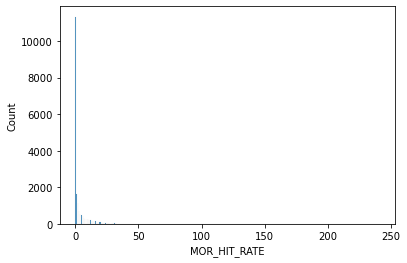

```python
sns.histplot(donors['MOR_HIT_RATE'])
plt.show()
```

It seems that the vast majority of observations for this feature equals 0. It might be a good idea to transform this feature into a category and redefine its definition to:

- `MOR_HIT_RATE`: equal to 1 if the person has responded to another organization's mail, 0 if they haven't.

```python
donors["MOR_HIT_RATE"] = np.where((donors["MOR_HIT_RATE"] != 0), "1", donors["MOR_HIT_RATE"])
donors["MOR_HIT_RATE"] = pd.Categorical(donors["MOR_HIT_RATE"])
donors["MOR_HIT_RATE"].unique()
```

```
['0', '1']
Categories (2, object): ['0', '1']
```

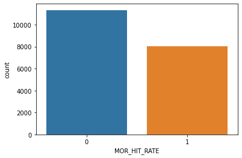

```python
sns.countplot(x=donors['MOR_HIT_RATE'])
plt.show()
```

Just like we saw with `MEDIAN_HOME_VALUE`, there are other numerical values where 0 values might not make sense: `DONOR_AGE` and `MEDIAN_HOUSEHOLD_INCOME`. However, for these 2 features, we will not assume that these values are errors, as there are some instances where they might be correct:

- For `DONOR_AGE`, the donation could have been done in the name of a baby or a newborn.
- For `MEDIAN_HOUSEHOLD_INCOME`, the donors could have been unemployed and, obviously, not have any income.

These are 2 special cases that need further evaluation. It might be worth it to further explore these possibilities

- **DONOR_AGE**

```python
donors[donors.DONOR_AGE == 0]
```

|  | TARGET_B | TARGET_D | DONOR_AGE | IN_HOUSE | URBANICITY | SES | HOME_OWNER | DONOR_GENDER | PUBLISHED_PHONE | MOR_HIT_RATE | MEDIAN_HOME_VALUE | MEDIAN_HOUSEHOLD_INCOME | PCT_OWNER_OCCUPIED | PCT_MILITARY | PCT_VETERANS | RECENCY_STATUS_96NK | FREQUENCY_STATUS_97NK | RECENT_RESPONSE_PROP | RECENT_AVG_GIFT_AMT | RECENT_CARD_RESPONSE_PROP | RECENT_AVG_CARD_GIFT_AMT | RECENT_CARD_RESPONSE_COUNT | MONTHS_SINCE_LAST_PROM_RESP | LIFETIME_AVG_GIFT_AMT | LAST_GIFT_AMT | CARD_PROM_12 | MONTHS_SINCE_LAST_GIFT | MONTHS_SINCE_FIRST_GIFT | FILE_CARD_GIFT | … |
| --- | --- | --- | --- | --- | --- | --- | --- | --- | --- | --- | --- | --- | --- | --- | --- | --- | --- | --- | --- | --- | --- | --- | --- | --- | --- | --- | --- | --- | --- | --- |
| 8967 | 0 | NaN | 0 | 0 | S | 2.0 | U | M | 1 | 0 | 1083.0 | 374 | 72 | 0 | 27 | A | 3 | 0.250 | 14.0 | 0.375 | 14.33 | 3 | 21.0 | 11.0 | 14.0 | 6 | 21 | 75 | 4 | … |
| 13698 | 0 | NaN | 0 | 0 | C | 1.0 | H | M | 1 | 1 | 705.0 | 266 | 97 | 0 | 42 | A | 3 | 0.222 | 35.5 | 0.222 | 35.00 | 2 | 18.0 | 24.0 | 37.0 | 6 | 18 | 127 | 6 | … |

There are only 2 observations where the donor's age is 0. However, contrary to the justifications we presented before, it doesn't seem to be the case of someone donating in the name of a child:

- Donor 8967 seems to have donated for the first time 75 months ago. Even if the first donation was done in the name of a child, there is no way the age would be the same after these 75 months. So, we conclude that this is a mistake in the data.
- Donor 13698 is listed as a homeowner. Even if the donation was done in the name of a child, there is no way that donor would be a homeowner. Also, its first donation was done 127 months ago. With this, we conclude that this age value is also a mistake.

With these two conclusions, we will have to find a way to correct these mistakes. We will do the same process we did for the missing values, replacing the `DONOR_AGE` value for its median.

```python
donors["DONOR_AGE"] = np.where((donors["DONOR_AGE"] == 0), ageMedian, donors["DONOR_AGE"])
donors[donors.DONOR_AGE == 0]
```

|  | TARGET_B | TARGET_D | DONOR_AGE | IN_HOUSE | URBANICITY | SES | HOME_OWNER | DONOR_GENDER | PUBLISHED_PHONE | MOR_HIT_RATE | MEDIAN_HOME_VALUE | MEDIAN_HOUSEHOLD_INCOME | PCT_OWNER_OCCUPIED | PCT_MILITARY | PCT_VETERANS | RECENCY_STATUS_96NK | FREQUENCY_STATUS_97NK | RECENT_RESPONSE_PROP | RECENT_AVG_GIFT_AMT | RECENT_CARD_RESPONSE_PROP | RECENT_AVG_CARD_GIFT_AMT | RECENT_CARD_RESPONSE_COUNT | MONTHS_SINCE_LAST_PROM_RESP | LIFETIME_AVG_GIFT_AMT | LAST_GIFT_AMT | CARD_PROM_12 | MONTHS_SINCE_LAST_GIFT | MONTHS_SINCE_FIRST_GIFT | FILE_CARD_GIFT | … |
| --- | --- | --- | --- | --- | --- | --- | --- | --- | --- | --- | --- | --- | --- | --- | --- | --- | --- | --- | --- | --- | --- | --- | --- | --- | --- | --- | --- | --- | --- | --- |

- **MEDIAN_HOUSEHOLD_INCOME**

```python
donors[donors.MEDIAN_HOUSEHOLD_INCOME == 0].shape
```

```
(174, 30)
```

This is a more complicated situation. There are 174 cases where MEDIAN_HOUSEHOLD_INCOME is 0 so we can't investigate each observation individually.

```python
donors[donors.MEDIAN_HOUSEHOLD_INCOME == 0].describe()
```

|  | TARGET_B | TARGET_D | DONOR_AGE | IN_HOUSE | SES | PUBLISHED_PHONE | MEDIAN_HOME_VALUE | MEDIAN_HOUSEHOLD_INCOME | PCT_OWNER_OCCUPIED | PCT_MILITARY | PCT_VETERANS | FREQUENCY_STATUS_97NK | RECENT_RESPONSE_PROP | RECENT_AVG_GIFT_AMT | RECENT_CARD_RESPONSE_PROP | RECENT_AVG_CARD_GIFT_AMT | RECENT_CARD_RESPONSE_COUNT | MONTHS_SINCE_LAST_PROM_RESP | LIFETIME_AVG_GIFT_AMT | LAST_GIFT_AMT | CARD_PROM_12 | MONTHS_SINCE_LAST_GIFT | MONTHS_SINCE_FIRST_GIFT | FILE_CARD_GIFT |
| --- | --- | --- | --- | --- | --- | --- | --- | --- | --- | --- | --- | --- | --- | --- | --- | --- | --- | --- | --- | --- | --- | --- | --- | --- |
| count | 174.000000 | 35.000000 | 174.000000 | 174.000000 | 174.000000 | 174.000000 | 174.000000 | 174.0 | 174.000000 | 174.000000 | 174.000000 | 174.000000 | 174.000000 | 174.000000 | 174.000000 | 174.000000 | 174.000000 | 174.000000 | 174.000000 | 174.000000 | 174.000000 | 174.000000 | 174.000000 | 174.000000 |
| mean | 0.201149 | 16.771429 | 56.379310 | 0.051724 | 2.454023 | 0.155172 | 749.494253 | 0.0 | 1.620690 | 2.356322 | 16.275862 | 1.942529 | 0.190322 | 15.828908 | 0.245305 | 13.094253 | 1.879310 | 19.396552 | 13.111667 | 16.994253 | 5.367816 | 18.735632 | 65.074713 | 5.074713 |
| std | 0.402016 | 11.581135 | 12.400113 | 0.222109 | 0.971062 | 0.363114 | 30.729991 | 0.0 | 11.759381 | 12.660965 | 16.329830 | 1.089692 | 0.118680 | 9.647136 | 0.183676 | 10.708811 | 1.490753 | 3.421826 | 6.419918 | 9.032054 | 1.273246 | 3.411845 | 36.337375 | 4.477322 |
| min | 0.000000 | 1.000000 | 7.000000 | 0.000000 | 1.000000 | 0.000000 | 675.000000 | 0.0 | 0.000000 | 0.000000 | 0.000000 | 1.000000 | 0.000000 | 0.000000 | 0.000000 | 0.000000 | 0.000000 | 15.000000 | 3.270000 | 3.000000 | 1.000000 | 4.000000 | 16.000000 | 0.000000 |
| 25% | 0.000000 | 10.000000 | 51.000000 | 0.000000 | 2.000000 | 0.000000 | 747.000000 | 0.0 | 0.000000 | 0.000000 | 0.000000 | 1.000000 | 0.112750 | 10.000000 | 0.111000 | 5.542500 | 1.000000 | 17.000000 | 8.807500 | 10.000000 | 5.000000 | 16.000000 | 33.000000 | 2.000000 |
| 50% | 0.000000 | 13.000000 | 60.000000 | 0.000000 | 2.000000 | 0.000000 | 747.000000 | 0.0 | 0.000000 | 0.000000 | 14.000000 | 2.000000 | 0.167000 | 15.000000 | 0.250000 | 12.000000 | 2.000000 | 18.000000 | 11.730000 | 15.000000 | 6.000000 | 18.000000 | 54.500000 | 3.500000 |
| 75% | 0.000000 | 25.000000 | 60.000000 | 0.000000 | 3.000000 | 0.000000 | 747.000000 | 0.0 | 0.000000 | 0.000000 | 31.000000 | 3.000000 | 0.237250 | 20.000000 | 0.333000 | 18.000000 | 3.000000 | 21.000000 | 16.395000 | 20.000000 | 6.000000 | 21.000000 | 92.250000 | 7.000000 |
| max | 1.000000 | 50.000000 | 85.000000 | 1.000000 | 4.000000 | 1.000000 | 1125.000000 | 0.0 | 99.000000 | 93.000000 | 50.000000 | 4.000000 | 0.750000 | 87.500000 | 1.000000 | 75.000000 | 8.000000 | 32.000000 | 38.000000 | 60.000000 | 13.000000 | 26.000000 | 130.000000 | 21.000000 |

There seems to be a lot of people with `MEDIAN_HOUSEHOLD_INCOME` = 0 that have `MEDIAN_HOME_VALUE` equal to 747, the median for this feature. This could happen because we imputed the median where `MEDIAN_HOME_VALUE` was 0. If both `MEDIAN_HOME_VALUE` and `MEDIAN_HOUSEHOLD_INCOME` were 0, it could be the case that these features were filled as 0 because there were no known values for these donors. However, as we have no way to confirm this was the case, we will just leave these values as is and assume the previous justification (unemployed donors) to be true.

## Categorical Attributes

To make it easier to visualize the categorical variables we will create a function that evaluates the differences in donation amount and donation type between groups.

```python
def plot_categorical(var, data=donors):
    """
    Creates a count plot, a bar plot for DONATION_TYPE, the mean for TARGET_D and a boxplot for TARGET_D for a
    categorical variable of the donors dataset.
    Requires: var is a string, the name of a column of the donors dataset.
    """
    # countplot
    sns.countplot(x=var, data = data)
    plt.show()

    # barplot
    cross_table = pd.crosstab(index=data[var], columns=data["DONATION_TYPE"])
    cross_table.plot(kind="bar", figsize=(6,6))
    plt.show()

    # boxplot
    sns.boxplot(x=var, y='TARGET_D', data=data)
    plt.show()

    # mean
    mean = data["TARGET_D"].groupby(data[var]).mean().sort_values(ascending=False)
    print(mean)
```

```python
activedonors = donors.loc[activeIndex]
activedonors.head(2)
```

|  | TARGET_B | TARGET_D | DONOR_AGE | IN_HOUSE | URBANICITY | SES | HOME_OWNER | DONOR_GENDER | PUBLISHED_PHONE | MOR_HIT_RATE | MEDIAN_HOME_VALUE | MEDIAN_HOUSEHOLD_INCOME | PCT_OWNER_OCCUPIED | PCT_MILITARY | PCT_VETERANS | RECENCY_STATUS_96NK | FREQUENCY_STATUS_97NK | RECENT_RESPONSE_PROP | RECENT_AVG_GIFT_AMT | RECENT_CARD_RESPONSE_PROP | RECENT_AVG_CARD_GIFT_AMT | RECENT_CARD_RESPONSE_COUNT | MONTHS_SINCE_LAST_PROM_RESP | LIFETIME_AVG_GIFT_AMT | LAST_GIFT_AMT | CARD_PROM_12 | MONTHS_SINCE_LAST_GIFT | MONTHS_SINCE_FIRST_GIFT | FILE_CARD_GIFT | … |
| --- | --- | --- | --- | --- | --- | --- | --- | --- | --- | --- | --- | --- | --- | --- | --- | --- | --- | --- | --- | --- | --- | --- | --- | --- | --- | --- | --- | --- | --- | --- |
| 1 | 1 | 10.0 | 79.0 | 0 | R | 2.0 | H | M | 0 | 0 | 334.0 | 212 | 72 | 0 | 41 | S | 2 | 0.235 | 15.0 | 0.250 | 15.0 | 2 | 11.0 | 14.72 | 17.0 | 7 | 7 | 122 | 12 | … |
| 7 | 1 | 5.0 | 79.0 | 0 | C | 2.0 | H | F | 0 | 0 | 1004.0 | 189 | 95 | 3 | 44 | A | 4 | 0.400 | 5.0 | 0.444 | 5.0 | 4 | 12.0 | 5.05 | 5.0 | 9 | 9 | 91 | 8 | … |

```python
donors.DONOR_GENDER =donors.DONOR_GENDER.replace('A', 'U')
```

```python
donors.FREQUENCY_STATUS_97NK.value_counts()
```

```
1    9118
2    4191
3    3318
4    2745
Name: FREQUENCY_STATUS_97NK, dtype: int64
```

```python
donors.HOME_OWNER.value_counts(normalize=True)
```

```
H    0.547491
U    0.452509
Name: HOME_OWNER, dtype: float64
```

```python
donors.loc[donors.TARGET_D !=0].IN_HOUSE.value_counts(normalize=True)
```

```
0    0.926802
1    0.073198
Name: IN_HOUSE, dtype: float64
```

- **URBANICITY**

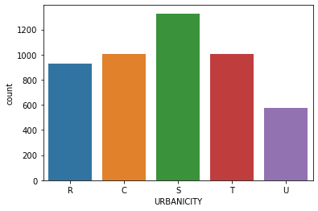

```python
sns.countplot(x='URBANICITY', data=activedonors)
```

**Suburban** group is the highest among donors. **Urban** donors are the minority.

```python
# Calculating mean donation amount by Urbanicity group
activedonors["TARGET_D"].groupby(activedonors["URBANICITY"]).mean().sort_values(ascending=False)
```

```
URBANICITY
S    17.036895
U    16.673744
T    15.082008
C    15.028330
R    14.184455
Name: TARGET_D, dtype: float64
```

```python
urban_table = pd.crosstab(index=activedonors["URBANICITY"], columns=activedonors["DONATION_TYPE"])
urban_table
```

| DONATION_TYPE URBANICITY | A | B | C | D | E |
| --- | --- | --- | --- | --- | --- |
| C | 19 | 264 | 194 | 285 | 244 |
| R | 17 | 233 | 168 | 249 | 260 |
| S | 40 | 439 | 285 | 318 | 245 |
| T | 22 | 287 | 194 | 244 | 259 |
| U | 16 | 190 | 111 | 136 | 124 |

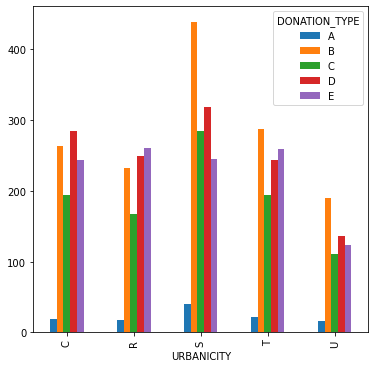

```python
urban_table.plot(kind="bar", figsize=(6,6))
```

#### SES

We know this is a classification for socio-economic features but we don't yet know the order of the groups. We'll use `MEDIAN_HOUSEHOLD_INCOME` to evaluate this as it is a similar socio-economic feature.

```python
donors["MEDIAN_HOUSEHOLD_INCOME"].groupby(donors["SES"]).mean().sort_values(ascending=False)
```

```
SES
1.0    481.112930
2.0    303.609776
3.0    223.488414
4.0    194.651163
Name: MEDIAN_HOUSEHOLD_INCOME, dtype: float64
```

It seems SES group 1 is the highest group and 4 is the lowest, meaning the order is descending, just like it happens in `DONATION_TYPE`.

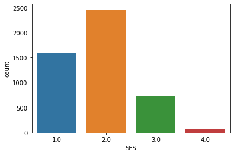

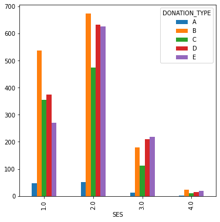

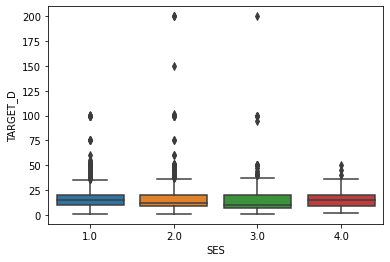

```
SES
1.0    17.125597
4.0    15.565217
2.0    15.052941
3.0    14.303888
Name: TARGET_D, dtype: float64
```

```python
plot_categorical("SES", activedonors)
```

SES group 2 is the biggest group, followed by 1, 3 and 4. This happens for both all donors and active donors.

Among active donors, the SES group 1 are the highest donors, by a significant margin. However, group 2 is the majority. Between SES groups, the most frequent donation types are **B**, **D** and **E**. Group 4 donors are a significant minority but are the second best group of donors when it comes to donation amounts, something that is surprising considering this is the lowest group when it comes to `PER_CAPITA_INCOME`.

#### RECENCY_STATUS_96NK

```python
donors["RECENCY_STATUS_96NK"].groupby(donors["RECENCY_STATUS_96NK"]).count()
```

```
RECENCY_STATUS_96NK
A    11918
E      427
F     1521
L       93
N     1192
S     4221
Name: RECENCY_STATUS_96NK, dtype: int64
```

The groups are imbalanced, with class A and S being a clear majority over the rest. Lapsing donors (L) are a very small number when compared to the other groups.

```python
activedonors["RECENCY_STATUS_96NK"].groupby(activedonors["RECENCY_STATUS_96NK"]).count()
```

```
RECENCY_STATUS_96NK
A    2794
E     132
F     257
L      17
N     264
S    1379
Name: RECENCY_STATUS_96NK, dtype: int64
```

We can see that active donors follow the same pattern: active and star donors are the majority, lapsing donors are the clear minority.

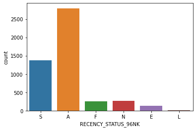

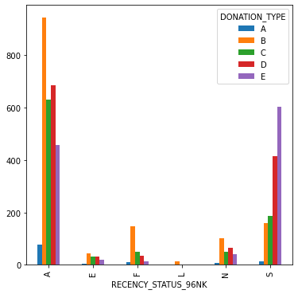

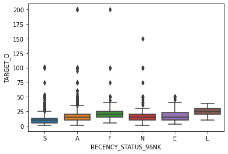

```
RECENCY_STATUS_96NK
L    24.764706
F    21.729416
N    17.654167
E    17.136364
A    16.995004
S    11.063452
Name: TARGET_D, dtype: float64
```

```python
plot_categorical("RECENCY_STATUS_96NK", activedonors)
```

Most individuals who donated to the last campaign were active or Star donors.

The highest donors are lapsing donors (L), even though this is a clear minority. It would be interesting to find some kind of way to make these donors be more active as they seem to be the most generous donors.

Groups A and S, the most frequent donor types, give the lowest amounts with, surprisingly, star donors being the lowest donors by a significant margin. We can hypothesize that, once a donor becomes a star donor, he or she stops giving as much money as before.

We also see that first-time donors (F) are the second most-generous. Aside from the obvious fact that more donors equal more donations, gathering more first-time donors is very important as these are a big source of donations.

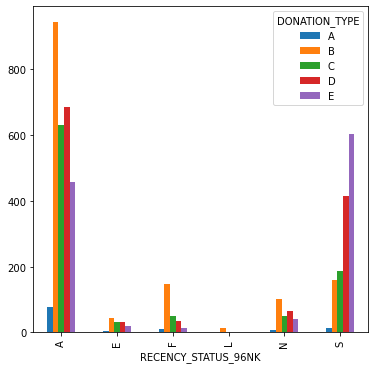

```python
cross_table = pd.crosstab(index=activedonors.loc[(donors.TARGET_D != 0)]['RECENCY_STATUS_96NK'],
                          columns=activedonors.loc[(donors.TARGET_D != 0)]["DONATION_TYPE"])
cross_table.plot(kind="bar", figsize=(6,6))
plt.show()
```

We can assume that the communcation for the campaign was not done via phone due to the fact that nearly half of the donors had their phone number published while the remaining did not. Having a phone number in the database didn't seem to influence the donation.

```python
activedonors.TARGET_B.groupby(activedonors["PUBLISHED_PHONE"]).count()
```

```
PUBLISHED_PHONE
0    2446
1    2397
Name: TARGET_B, dtype: int64
```

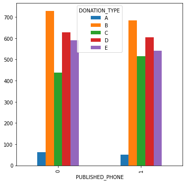

```python
cross_table = pd.crosstab(index=activedonors.loc[(donors.TARGET_D != 0)]['PUBLISHED_PHONE'],
                          columns=activedonors.loc[(donors.TARGET_D != 0)]["DONATION_TYPE"])
cross_table.plot(kind="bar", figsize=(6,6))
plt.show()
```

## 4. Visualizing the Data

For this section, we have the goal to go more in depth to generate some insights and/or confirm some assumptions we had about the data.

We have chosen to keep the below scatterplot as it indicates an interesting point which is the fact that a higher amount of card promotions sent in the last 12 months doesn't necessarily translate into an individual donating more. In fact, the 3 outliers we observe representing the highest donation amounts were made by individuals which were sent 6 or less cards.

More isn't always better.

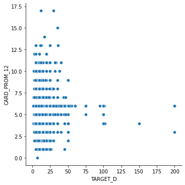

```python
sns.relplot(x="TARGET_D", y="CARD_PROM_12", data=donors)
```

Adding to the previous point, the below graph illustrates the fact that donors and non-donors followed a relatively similar distribution when it came to the card promotions received (with mean close to 5 calls for both groups) . Thus, receiving more mail also wouldn't necessarily make an individual donate.

```python
donors.loc[(donors.TARGET_B==1)].CARD_PROM_12.mean() #donors avg calls
```

```
5.452405533760066
```

```python
donors.loc[(donors.TARGET_B==0)].CARD_PROM_12.mean() #non donors avg calls
```

```
5.338701906531764
```

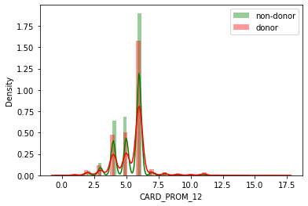

```python
sns.distplot(donors['CARD_PROM_12'][donors['TARGET_B']==0], color='g', label = 'non-donor')
sns.distplot(donors['CARD_PROM_12'][donors['TARGET_B']==1], color='r', label = 'donor')
plt.legend(loc='best')
fig.tight_layout()
plt.show()
```

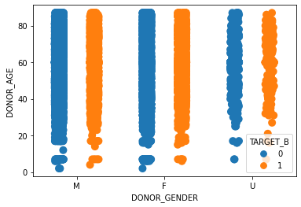

```python
sns.stripplot(x="DONOR_GENDER", y="DONOR_AGE", hue="TARGET_B", data=donors, dodge=True, size=10)
```

Both sexes seem to be equally represented when it comes to ages, among donors and non-donors.

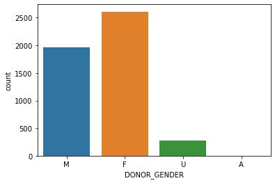

```python
sns.countplot(x="DONOR_GENDER", data=activedonors)
```

```python
activedonors["TARGET_D"].groupby(activedonors["DONOR_GENDER"]).mean().sort_values(ascending=False)
```

```
DONOR_GENDER
A    100.000000
M     16.225061
U     16.004465
F     15.100774
Name: TARGET_D, dtype: float64
```

It is interesting to point out that females are the majority between active donors. However, despite donating less frequently, males donated on a higher average dollar amount (16.2 dollars compared to 15 from females and 16 from unknown).

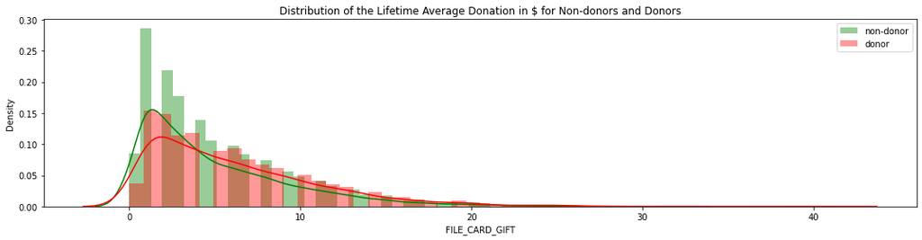

```python
fig, ax = plt.subplots(1, 1, figsize=(15,4))
sns.distplot(donors['FILE_CARD_GIFT'][donors['TARGET_B']==0], color='g', label = 'non-donor')
sns.distplot(donors['FILE_CARD_GIFT'][donors['TARGET_B']==1], color='r', label = 'donor')
plt.legend(loc='best')
plt.title('Distribution of the Lifetime Average Donation in $ for Non-donors and Donors')
fig.tight_layout()
plt.show()
```

The above plot leaves the question hanging - was last year's card promotion effective?

As we can observe, the distribution of the lifetime average donation in dollars for donors and non-donors was considerabily similar. This would mean that individuals with similar donation habits, last year acted completely differently. Ideally we would think that the charity organization could detect and target more effeciently those with previous high donation past and get them to donate.

```python
activedonors["TARGET_D"].groupby(activedonors["FREQUENCY_STATUS_97NK"]).mean().sort_values(ascending=False)
```

```
FREQUENCY_STATUS_97NK
1    20.506009
2    16.995739
3    11.440678
4     9.553960
Name: TARGET_D, dtype: float64
```

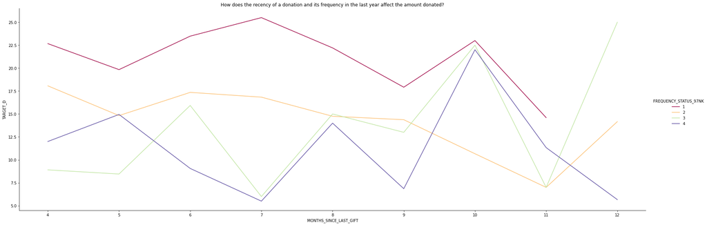

```python
sns.relplot(
    data=activedonors[activedonors.MONTHS_SINCE_LAST_GIFT<=12],
    x="MONTHS_SINCE_LAST_GIFT", y="TARGET_D", hue= 'FREQUENCY_STATUS_97NK', kind='line', facet_kws=dict(sharex=False),
    height=8, aspect=3, ci=None, palette='Spectral')
plt.title('How does the recency of a donation and its frequency in the last year affect the amount donated?')
plt.show();
```

Generally, higher donations in dollar amount were made by individuals who had donated once in the past 12 months.

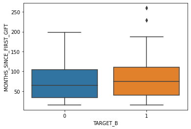

```python
sns.boxplot(x='TARGET_B', y='MONTHS_SINCE_FIRST_GIFT', data=donors)
plt.show()
```

The box plot above allows us to draw the conclusion that people who donated in the last donation drive have, in general, donated for the first time a longer time ago than non-donors.